# Results: st104d02.sas

Stepwise Model Selection for SalePrice - AIC

The GLMSELECT Procedure

| Data Set | STAT1.AMESHOUSING3 |
| --- | --- |
| Dependent Variable | SalePrice |
| Selection Method | Stepwise |
| Select Criterion | AIC |
| Stop Criterion | AIC |
| Effect Hierarchy Enforced | None |

| Number of Observations Read | 300 |
| --- | --- |
| Number of Observations Used | 300 |

| Dimensions |  |
| --- | --- |
| Number of Effects | 9 |
| Number of Parameters | 9 |

Stepwise Model Selection for SalePrice - AIC

The GLMSELECT Procedure

Stepwise Selection: Step 0

Effect Entered: Intercept

| Analysis of Variance Source | Analysis of Variance DF | Analysis of Variance Sum of Squares | Analysis of Variance Mean Square | Analysis of Variance F Value |
| --- | --- | --- | --- | --- |
| Model | 0 | 0 | . | . |
| Error | 299 | 4.232235E11 | 1415463276 |  |
| Corrected Total | 299 | 4.232235E11 |  |  |

| Root MSE | 37623 |
| --- | --- |
| Dependent Mean | 137525 |
| R-Square | 0.0000 |
| Adj R-Sq | 0.0000 |
| AIC | 6624.21515 |
| AICC | 6624.25555 |
| SBC | 6325.91893 |

| Parameter Estimates Parameter | Parameter Estimates DF | Parameter Estimates Estimate | Parameter Estimates Standard Error | Parameter Estimates t Value |
| --- | --- | --- | --- | --- |
| Intercept | 1 | 137525 | 2172.144314 | 63.31 |

Stepwise Model Selection for SalePrice - AIC

The GLMSELECT Procedure

Stepwise Selection: Step 1

Effect Entered: Basement_Area

| Analysis of Variance Source | Analysis of Variance DF | Analysis of Variance Sum of Squares | Analysis of Variance Mean Square | Analysis of Variance F Value |
| --- | --- | --- | --- | --- |
| Model | 1 | 2.012418E11 | 2.012418E11 | 270.16 |
| Error | 298 | 2.219817E11 | 744904950 |  |
| Corrected Total | 299 | 4.232235E11 |  |  |

| Root MSE | 27293 |
| --- | --- |
| Dependent Mean | 137525 |
| R-Square | 0.4755 |
| Adj R-Sq | 0.4737 |
| AIC | 6432.62346 |
| AICC | 6432.70454 |
| SBC | 6138.03102 |

| Parameter Estimates Parameter | Parameter Estimates DF | Parameter Estimates Estimate | Parameter Estimates Standard Error | Parameter Estimates t Value |
| --- | --- | --- | --- | --- |
| Intercept | 1 | 73904 | 4179.193780 | 17.68 |
| Basement_Area | 1 | 72.107717 | 4.387055 | 16.44 |

| Entry Candidates Rank | Entry Candidates Effect | Entry Candidates AIC |
| --- | --- | --- |
| 1 | Basement_Area | 6432.6235 |
| 2 | Gr_Liv_Area | 6461.1877 |
| 3 | Age_Sold | 6483.4097 |
| 4 | Total_Bathroom | 6492.0868 |
| 5 | Garage_Area | 6503.7574 |
| 6 | Deck_Porch_Area | 6561.6989 |
| 7 | Lot_Area | 6606.3138 |
| 8 | Bedroom_AbvGr | 6617.8389 |

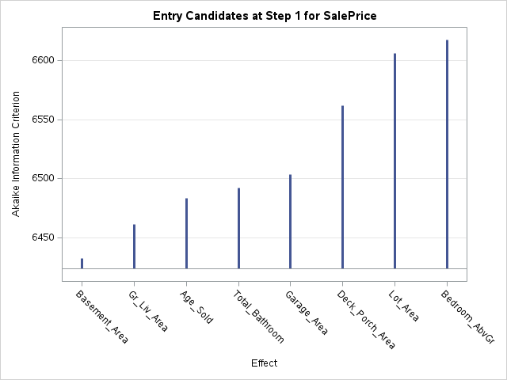

Stepwise Model Selection for SalePrice - AIC

The GLMSELECT Procedure

Stepwise Selection: Step 2

Effect Entered: Gr_Liv_Area

| Analysis of Variance Source | Analysis of Variance DF | Analysis of Variance Sum of Squares | Analysis of Variance Mean Square | Analysis of Variance F Value |
| --- | --- | --- | --- | --- |
| Model | 2 | 2.64483E11 | 1.322415E11 | 247.42 |
| Error | 297 | 1.587405E11 | 534479711 |  |
| Corrected Total | 299 | 4.232235E11 |  |  |

| Root MSE | 23119 |
| --- | --- |
| Dependent Mean | 137525 |
| R-Square | 0.6249 |
| Adj R-Sq | 0.6224 |
| AIC | 6334.02620 |
| AICC | 6334.16179 |
| SBC | 6043.13755 |

| Parameter Estimates Parameter | Parameter Estimates DF | Parameter Estimates Estimate | Parameter Estimates Standard Error | Parameter Estimates t Value |
| --- | --- | --- | --- | --- |
| Intercept | 1 | 12664 | 6650.339855 | 1.90 |
| Gr_Liv_Area | 1 | 69.606974 | 6.399091 | 10.88 |
| Basement_Area | 1 | 52.309702 | 4.137885 | 12.64 |

| Entry Candidates Rank | Entry Candidates Effect | Entry Candidates AIC |
| --- | --- | --- |
| 1 | Gr_Liv_Area | 6334.0262 |
| 2 | Age_Sold | 6342.0095 |
| 3 | Garage_Area | 6351.3061 |
| 4 | Total_Bathroom | 6376.4084 |
| 5 | Deck_Porch_Area | 6405.4472 |
| 6 | Lot_Area | 6431.9372 |
| 7 | Bedroom_AbvGr | 6434.0931 |

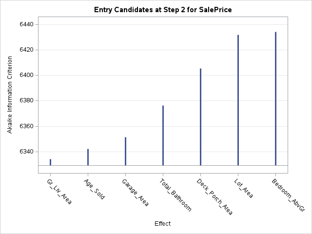

Stepwise Model Selection for SalePrice - AIC

The GLMSELECT Procedure

Stepwise Selection: Step 3

Effect Entered: Age_Sold

| Analysis of Variance Source | Analysis of Variance DF | Analysis of Variance Sum of Squares | Analysis of Variance Mean Square | Analysis of Variance F Value |
| --- | --- | --- | --- | --- |
| Model | 3 | 3.207148E11 | 1.069049E11 | 308.69 |
| Error | 296 | 1.025087E11 | 346313132 |  |
| Corrected Total | 299 | 4.232235E11 |  |  |

| Root MSE | 18609 |
| --- | --- |
| Dependent Mean | 137525 |
| R-Square | 0.7578 |
| Adj R-Sq | 0.7553 |
| AIC | 6204.82927 |
| AICC | 6205.03335 |
| SBC | 5917.64440 |

| Parameter Estimates Parameter | Parameter Estimates DF | Parameter Estimates Estimate | Parameter Estimates Standard Error | Parameter Estimates t Value |
| --- | --- | --- | --- | --- |
| Intercept | 1 | 53400 | 6235.076995 | 8.56 |
| Gr_Liv_Area | 1 | 68.106646 | 5.152294 | 13.22 |
| Basement_Area | 1 | 36.329120 | 3.559067 | 10.21 |
| Age_Sold | 1 | -543.493346 | 42.651840 | -12.74 |

| Entry Candidates Rank | Entry Candidates Effect | Entry Candidates AIC |
| --- | --- | --- |
| 1 | Age_Sold | 6204.8293 |
| 2 | Garage_Area | 6264.6656 |
| 3 | Total_Bathroom | 6296.3441 |
| 4 | Deck_Porch_Area | 6314.2811 |
| 5 | Bedroom_AbvGr | 6314.4078 |
| 6 | Lot_Area | 6335.7989 |

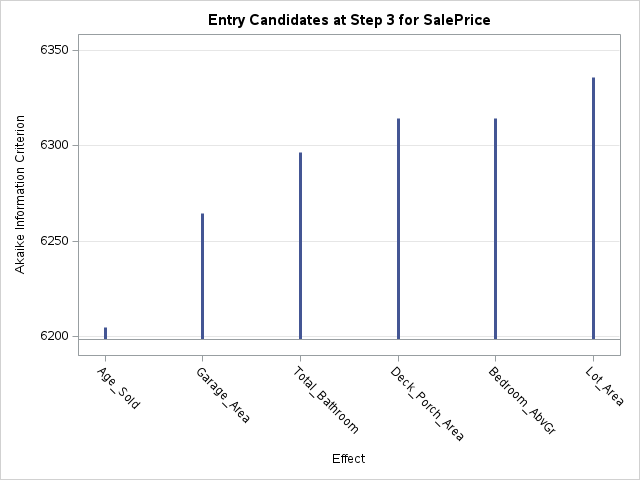

Stepwise Model Selection for SalePrice - AIC

The GLMSELECT Procedure

Stepwise Selection: Step 4

Effect Entered: Garage_Area

| Analysis of Variance Source | Analysis of Variance DF | Analysis of Variance Sum of Squares | Analysis of Variance Mean Square | Analysis of Variance F Value |
| --- | --- | --- | --- | --- |
| Model | 4 | 3.33571E11 | 83392754480 | 274.40 |
| Error | 295 | 89652501590 | 303906785 |  |
| Corrected Total | 299 | 4.232235E11 |  |  |

| Root MSE | 17433 |
| --- | --- |
| Dependent Mean | 137525 |
| R-Square | 0.7882 |
| Adj R-Sq | 0.7853 |
| AIC | 6166.62734 |
| AICC | 6166.91403 |
| SBC | 5883.14625 |

| Parameter Estimates Parameter | Parameter Estimates DF | Parameter Estimates Estimate | Parameter Estimates Standard Error | Parameter Estimates t Value |
| --- | --- | --- | --- | --- |
| Intercept | 1 | 43815 | 6023.907004 | 7.27 |
| Gr_Liv_Area | 1 | 61.238136 | 4.940722 | 12.39 |
| Basement_Area | 1 | 33.430181 | 3.363709 | 9.94 |
| Garage_Area | 1 | 42.984492 | 6.608851 | 6.50 |
| Age_Sold | 1 | -455.704354 | 42.173481 | -10.81 |

| Entry Candidates Rank | Entry Candidates Effect | Entry Candidates AIC |
| --- | --- | --- |
| 1 | Garage_Area | 6166.6273 |
| 2 | Deck_Porch_Area | 6184.1900 |
| 3 | Bedroom_AbvGr | 6194.0980 |
| 4 | Total_Bathroom | 6201.3633 |
| 5 | Lot_Area | 6201.6954 |

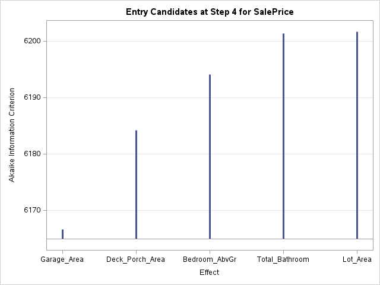

Stepwise Model Selection for SalePrice - AIC

The GLMSELECT Procedure

Stepwise Selection: Step 5

Effect Entered: Deck_Porch_Area

| Analysis of Variance Source | Analysis of Variance DF | Analysis of Variance Sum of Squares | Analysis of Variance Mean Square | Analysis of Variance F Value |
| --- | --- | --- | --- | --- |
| Model | 5 | 3.392788E11 | 67855752389 | 237.65 |
| Error | 294 | 83944757568 | 285526386 |  |
| Corrected Total | 299 | 4.232235E11 |  |  |

| Root MSE | 16898 |
| --- | --- |
| Dependent Mean | 137525 |
| R-Square | 0.8017 |
| Adj R-Sq | 0.7983 |
| AIC | 6148.89269 |
| AICC | 6149.27625 |
| SBC | 5869.11538 |

| Parameter Estimates Parameter | Parameter Estimates DF | Parameter Estimates Estimate | Parameter Estimates Standard Error | Parameter Estimates t Value |
| --- | --- | --- | --- | --- |
| Intercept | 1 | 46009 | 5859.485517 | 7.85 |
| Gr_Liv_Area | 1 | 58.386514 | 4.831268 | 12.09 |
| Basement_Area | 1 | 30.554240 | 3.323249 | 9.19 |
| Garage_Area | 1 | 40.158112 | 6.436997 | 6.24 |
| Deck_Porch_Area | 1 | 35.720258 | 7.989240 | 4.47 |
| Age_Sold | 1 | -447.254040 | 40.921927 | -10.93 |

| Entry Candidates Rank | Entry Candidates Effect | Entry Candidates AIC |
| --- | --- | --- |
| 1 | Deck_Porch_Area | 6148.8927 |
| 2 | Bedroom_AbvGr | 6158.7554 |
| 3 | Total_Bathroom | 6164.5138 |
| 4 | Lot_Area | 6166.4302 |

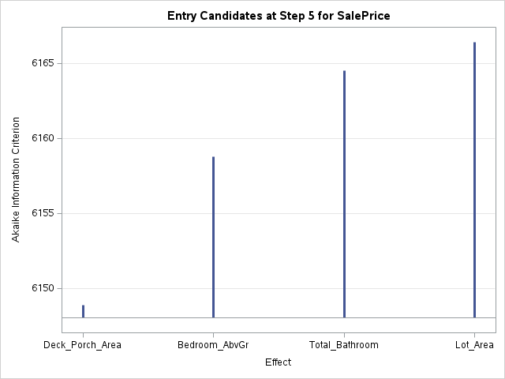

Stepwise Model Selection for SalePrice - AIC

The GLMSELECT Procedure

Stepwise Selection: Step 6

Effect Entered: Bedroom_AbvGr

| Analysis of Variance Source | Analysis of Variance DF | Analysis of Variance Sum of Squares | Analysis of Variance Mean Square | Analysis of Variance F Value |
| --- | --- | --- | --- | --- |
| Model | 6 | 3.410749E11 | 56845818595 | 202.75 |
| Error | 293 | 82148607939 | 280370676 |  |
| Corrected Total | 299 | 4.232235E11 |  |  |

| Root MSE | 16744 |
| --- | --- |
| Dependent Mean | 137525 |
| R-Square | 0.8059 |
| Adj R-Sq | 0.8019 |
| AIC | 6144.40398 |
| AICC | 6144.89882 |
| SBC | 5868.33046 |

| Parameter Estimates Parameter | Parameter Estimates DF | Parameter Estimates Estimate | Parameter Estimates Standard Error | Parameter Estimates t Value |
| --- | --- | --- | --- | --- |
| Intercept | 1 | 48620 | 5897.324643 | 8.24 |
| Gr_Liv_Area | 1 | 65.097413 | 5.472624 | 11.90 |
| Basement_Area | 1 | 31.279351 | 3.305546 | 9.46 |
| Garage_Area | 1 | 38.728785 | 6.403565 | 6.05 |
| Deck_Porch_Area | 1 | 32.487956 | 8.019119 | 4.05 |
| Age_Sold | 1 | -434.199118 | 40.877494 | -10.62 |
| Bedroom_AbvGr | 1 | -4189.095026 | 1655.065743 | -2.53 |

| Entry Candidates Rank | Entry Candidates Effect | Entry Candidates AIC |
| --- | --- | --- |
| 1 | Bedroom_AbvGr | 6144.4040 |
| 2 | Total_Bathroom | 6147.6813 |
| 3 | Lot_Area | 6148.3694 |

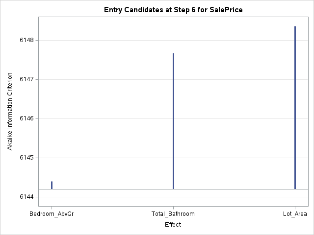

Stepwise Model Selection for SalePrice - AIC

The GLMSELECT Procedure

Stepwise Selection: Step 7

Effect Entered: Lot_Area

| Analysis of Variance Source | Analysis of Variance DF | Analysis of Variance Sum of Squares | Analysis of Variance Mean Square | Analysis of Variance F Value |
| --- | --- | --- | --- | --- |
| Model | 7 | 3.424508E11 | 48921543221 | 176.86 |
| Error | 292 | 80772716963 | 276618894 |  |
| Corrected Total | 299 | 4.232235E11 |  |  |

| Root MSE | 16632 |
| --- | --- |
| Dependent Mean | 137525 |
| R-Square | 0.8091 |
| Adj R-Sq | 0.8046 |
| AIC | 6141.33678 |
| AICC | 6141.95747 |
| SBC | 5868.96704 |

| Parameter Estimates Parameter | Parameter Estimates DF | Parameter Estimates Estimate | Parameter Estimates Standard Error | Parameter Estimates t Value |
| --- | --- | --- | --- | --- |
| Intercept | 1 | 47463 | 5880.674041 | 8.07 |
| Gr_Liv_Area | 1 | 65.303724 | 5.436672 | 12.01 |
| Basement_Area | 1 | 29.849078 | 3.345400 | 8.92 |
| Garage_Area | 1 | 36.309606 | 6.452405 | 5.63 |
| Deck_Porch_Area | 1 | 32.052554 | 7.967677 | 4.02 |
| Lot_Area | 1 | 0.708127 | 0.317512 | 2.23 |
| Age_Sold | 1 | -447.198682 | 41.019314 | -10.90 |
| Bedroom_AbvGr | 1 | -5042.766498 | 1687.928168 | -2.99 |

| Entry Candidates Rank | Entry Candidates Effect | Entry Candidates AIC |
| --- | --- | --- |
| 1 | Lot_Area | 6141.3368 |
| 2 | Total_Bathroom | 6143.7813 |

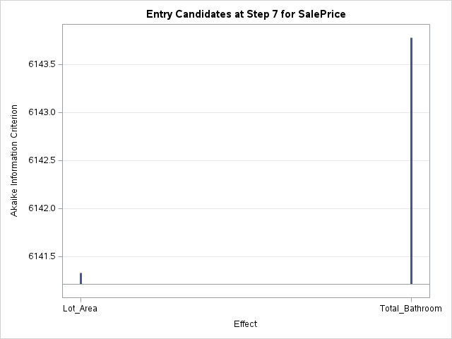

Stepwise Model Selection for SalePrice - AIC

The GLMSELECT Procedure

Stepwise Selection: Step 8

Effect Entered: Total_Bathroom

| Analysis of Variance Source | Analysis of Variance DF | Analysis of Variance Sum of Squares | Analysis of Variance Mean Square | Analysis of Variance F Value |
| --- | --- | --- | --- | --- |
| Model | 8 | 3.431321E11 | 42891512314 | 155.84 |
| Error | 291 | 80091420996 | 275228251 |  |
| Corrected Total | 299 | 4.232235E11 |  |  |

| Root MSE | 16590 |
| --- | --- |
| Dependent Mean | 137525 |
| R-Square | 0.8108 |
| Adj R-Sq | 0.8056 |
| AIC | 6140.79563 |
| AICC | 6141.55688 |
| SBC | 5872.12967 |

| Parameter Estimates Parameter | Parameter Estimates DF | Parameter Estimates Estimate | Parameter Estimates Standard Error | Parameter Estimates t Value |
| --- | --- | --- | --- | --- |
| Intercept | 1 | 44347 | 6191.271944 | 7.16 |
| Gr_Liv_Area | 1 | 63.197764 | 5.585739 | 11.31 |
| Basement_Area | 1 | 28.692184 | 3.417034 | 8.40 |
| Garage_Area | 1 | 35.754191 | 6.445840 | 5.55 |
| Deck_Porch_Area | 1 | 31.370539 | 7.959436 | 3.94 |
| Lot_Area | 1 | 0.699495 | 0.316761 | 2.21 |
| Age_Sold | 1 | -420.815037 | 44.219144 | -9.52 |
| Bedroom_AbvGr | 1 | -4834.848748 | 1688.858227 | -2.86 |
| Total_Bathroom | 1 | 3022.124723 | 1920.839066 | 1.57 |

| Entry Candidates Rank | Entry Candidates Effect | Entry Candidates AIC |
| --- | --- | --- |
| 1 | Total_Bathroom | 6140.7956 |

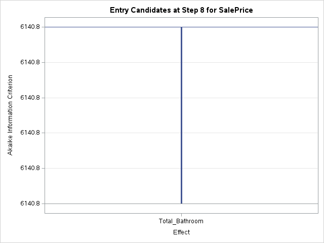

Stepwise Model Selection for SalePrice - AIC

The GLMSELECT Procedure

| Stepwise Selection Summary Step | Stepwise Selection Summary Effect Entered | Stepwise Selection Summary Effect Removed | Stepwise Selection Summary Number Effects In | Stepwise Selection Summary AIC |
| --- | --- | --- | --- | --- |
| 0 | Intercept |  | 1 | 6624.2151 |
| 1 | Basement_Area |  | 2 | 6432.6235 |
| 2 | Gr_Liv_Area |  | 3 | 6334.0262 |
| 3 | Age_Sold |  | 4 | 6204.8293 |
| 4 | Garage_Area |  | 5 | 6166.6273 |
| 5 | Deck_Porch_Area |  | 6 | 6148.8927 |
| 6 | Bedroom_AbvGr |  | 7 | 6144.4040 |
| 7 | Lot_Area |  | 8 | 6141.3368 |
| 8 | Total_Bathroom |  | 9 | 6140.7956* |

* Optimal Value of Criterion

| Selection stopped because all effects are in the final model. |
| --- |

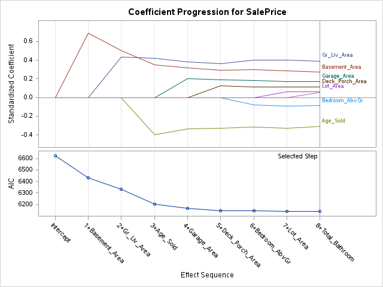

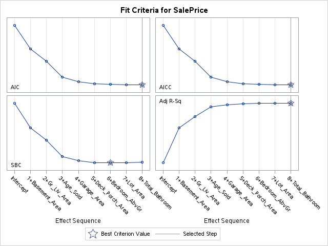

Stepwise Model Selection for SalePrice - AIC

The GLMSELECT Procedure

Selected Model

The selected model is the model at the last step (Step 8).

| Effects: | Intercept Gr_Liv_Area Basement_Area Garage_Area Deck_Porch_Area Lot_Area Age_Sold Bedroom_AbvGr Total_Bathroom |
| --- | --- |

| Analysis of Variance Source | Analysis of Variance DF | Analysis of Variance Sum of Squares | Analysis of Variance Mean Square | Analysis of Variance F Value |
| --- | --- | --- | --- | --- |
| Model | 8 | 3.431321E11 | 42891512314 | 155.84 |
| Error | 291 | 80091420996 | 275228251 |  |
| Corrected Total | 299 | 4.232235E11 |  |  |

| Root MSE | 16590 |
| --- | --- |
| Dependent Mean | 137525 |
| R-Square | 0.8108 |
| Adj R-Sq | 0.8056 |
| AIC | 6140.79563 |
| AICC | 6141.55688 |
| SBC | 5872.12967 |

| Parameter Estimates Parameter | Parameter Estimates DF | Parameter Estimates Estimate | Parameter Estimates Standard Error | Parameter Estimates t Value |
| --- | --- | --- | --- | --- |
| Intercept | 1 | 44347 | 6191.271944 | 7.16 |
| Gr_Liv_Area | 1 | 63.197764 | 5.585739 | 11.31 |
| Basement_Area | 1 | 28.692184 | 3.417034 | 8.40 |
| Garage_Area | 1 | 35.754191 | 6.445840 | 5.55 |
| Deck_Porch_Area | 1 | 31.370539 | 7.959436 | 3.94 |
| Lot_Area | 1 | 0.699495 | 0.316761 | 2.21 |
| Age_Sold | 1 | -420.815037 | 44.219144 | -9.52 |
| Bedroom_AbvGr | 1 | -4834.848748 | 1688.858227 | -2.86 |
| Total_Bathroom | 1 | 3022.124723 | 1920.839066 | 1.57 |

Stepwise Model Selection for SalePrice - BIC

The GLMSELECT Procedure

| Data Set | STAT1.AMESHOUSING3 |
| --- | --- |
| Dependent Variable | SalePrice |
| Selection Method | Stepwise |
| Select Criterion | BIC |
| Stop Criterion | BIC |
| Effect Hierarchy Enforced | None |

| Number of Observations Read | 300 |
| --- | --- |
| Number of Observations Used | 300 |

| Dimensions |  |
| --- | --- |
| Number of Effects | 9 |
| Number of Parameters | 9 |

Stepwise Model Selection for SalePrice - BIC

The GLMSELECT Procedure

Stepwise Selection: Step 0

Effect Entered: Intercept

| Analysis of Variance Source | Analysis of Variance DF | Analysis of Variance Sum of Squares | Analysis of Variance Mean Square | Analysis of Variance F Value |
| --- | --- | --- | --- | --- |
| Model | 0 | 0 | . | . |
| Error | 299 | 4.232235E11 | 1415463276 |  |
| Corrected Total | 299 | 4.232235E11 |  |  |

| Root MSE | 37623 |
| --- | --- |
| Dependent Mean | 137525 |
| R-Square | 0.0000 |
| Adj R-Sq | 0.0000 |
| AIC | 6624.21515 |
| AICC | 6624.25555 |
| BIC | 6321.30959 |
| C(p) | 1239.71831 |
| SBC | 6325.91893 |

| Parameter Estimates Parameter | Parameter Estimates DF | Parameter Estimates Estimate | Parameter Estimates Standard Error | Parameter Estimates t Value |
| --- | --- | --- | --- | --- |
| Intercept | 1 | 137525 | 2172.144314 | 63.31 |

Stepwise Model Selection for SalePrice - BIC

The GLMSELECT Procedure

Stepwise Selection: Step 1

Effect Entered: Basement_Area

| Analysis of Variance Source | Analysis of Variance DF | Analysis of Variance Sum of Squares | Analysis of Variance Mean Square | Analysis of Variance F Value |
| --- | --- | --- | --- | --- |
| Model | 1 | 2.012418E11 | 2.012418E11 | 270.16 |
| Error | 298 | 2.219817E11 | 744904950 |  |
| Corrected Total | 299 | 4.232235E11 |  |  |

| Root MSE | 27293 |
| --- | --- |
| Dependent Mean | 137525 |
| R-Square | 0.4755 |
| Adj R-Sq | 0.4737 |
| AIC | 6432.62346 |
| AICC | 6432.70454 |
| BIC | 6129.32244 |
| C(p) | 510.53666 |
| SBC | 6138.03102 |

| Parameter Estimates Parameter | Parameter Estimates DF | Parameter Estimates Estimate | Parameter Estimates Standard Error | Parameter Estimates t Value |
| --- | --- | --- | --- | --- |
| Intercept | 1 | 73904 | 4179.193780 | 17.68 |
| Basement_Area | 1 | 72.107717 | 4.387055 | 16.44 |

| Entry Candidates Rank | Entry Candidates Effect | Entry Candidates BIC |
| --- | --- | --- |
| 1 | Basement_Area | 6129.3224 |
| 2 | Gr_Liv_Area | 6157.6644 |
| 3 | Age_Sold | 6179.7247 |
| 4 | Total_Bathroom | 6188.3413 |
| 5 | Garage_Area | 6199.9327 |
| 6 | Deck_Porch_Area | 6257.5170 |
| 7 | Lot_Area | 6301.8947 |
| 8 | Bedroom_AbvGr | 6313.3634 |

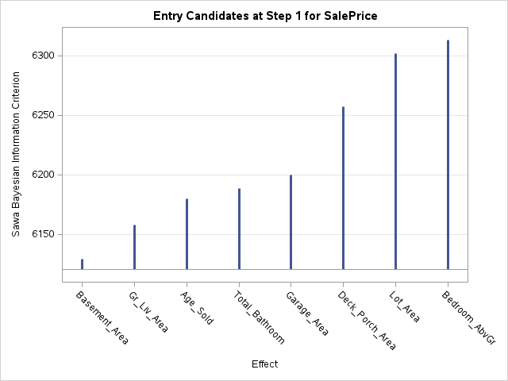

Stepwise Model Selection for SalePrice - BIC

The GLMSELECT Procedure

Stepwise Selection: Step 2

Effect Entered: Gr_Liv_Area

| Analysis of Variance Source | Analysis of Variance DF | Analysis of Variance Sum of Squares | Analysis of Variance Mean Square | Analysis of Variance F Value |
| --- | --- | --- | --- | --- |
| Model | 2 | 2.64483E11 | 1.322415E11 | 247.42 |
| Error | 297 | 1.587405E11 | 534479711 |  |
| Corrected Total | 299 | 4.232235E11 |  |  |

| Root MSE | 23119 |
| --- | --- |
| Dependent Mean | 137525 |
| R-Square | 0.6249 |
| Adj R-Sq | 0.6224 |
| AIC | 6334.02620 |
| AICC | 6334.16179 |
| BIC | 6030.68657 |
| C(p) | 282.75938 |
| SBC | 6043.13755 |

| Parameter Estimates Parameter | Parameter Estimates DF | Parameter Estimates Estimate | Parameter Estimates Standard Error | Parameter Estimates t Value |
| --- | --- | --- | --- | --- |
| Intercept | 1 | 12664 | 6650.339855 | 1.90 |
| Gr_Liv_Area | 1 | 69.606974 | 6.399091 | 10.88 |
| Basement_Area | 1 | 52.309702 | 4.137885 | 12.64 |

| Entry Candidates Rank | Entry Candidates Effect | Entry Candidates BIC |
| --- | --- | --- |
| 1 | Gr_Liv_Area | 6030.6866 |
| 2 | Age_Sold | 6038.5613 |
| 3 | Garage_Area | 6047.7342 |
| 4 | Total_Bathroom | 6072.5166 |
| 5 | Deck_Porch_Area | 6101.2106 |
| 6 | Lot_Area | 6127.4086 |
| 7 | Bedroom_AbvGr | 6129.5416 |

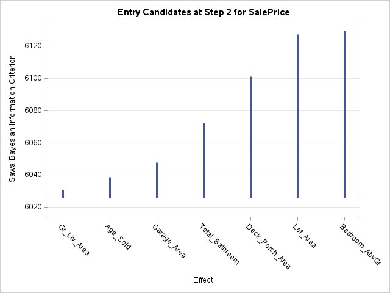

Stepwise Model Selection for SalePrice - BIC

The GLMSELECT Procedure

Stepwise Selection: Step 3

Effect Entered: Age_Sold

| Analysis of Variance Source | Analysis of Variance DF | Analysis of Variance Sum of Squares | Analysis of Variance Mean Square | Analysis of Variance F Value |
| --- | --- | --- | --- | --- |
| Model | 3 | 3.207148E11 | 1.069049E11 | 308.69 |
| Error | 296 | 1.025087E11 | 346313132 |  |
| Corrected Total | 299 | 4.232235E11 |  |  |

| Root MSE | 18609 |
| --- | --- |
| Dependent Mean | 137525 |
| R-Square | 0.7578 |
| Adj R-Sq | 0.7553 |
| AIC | 6204.82927 |
| AICC | 6205.03335 |
| BIC | 5903.19742 |
| C(p) | 80.44973 |
| SBC | 5917.64440 |

| Parameter Estimates Parameter | Parameter Estimates DF | Parameter Estimates Estimate | Parameter Estimates Standard Error | Parameter Estimates t Value |
| --- | --- | --- | --- | --- |
| Intercept | 1 | 53400 | 6235.076995 | 8.56 |
| Gr_Liv_Area | 1 | 68.106646 | 5.152294 | 13.22 |
| Basement_Area | 1 | 36.329120 | 3.559067 | 10.21 |
| Age_Sold | 1 | -543.493346 | 42.651840 | -12.74 |

| Entry Candidates Rank | Entry Candidates Effect | Entry Candidates BIC |
| --- | --- | --- |
| 1 | Age_Sold | 5903.1974 |
| 2 | Garage_Area | 5961.7128 |
| 3 | Total_Bathroom | 5992.7636 |
| 4 | Deck_Porch_Area | 6010.3666 |
| 5 | Bedroom_AbvGr | 6010.4910 |
| 6 | Lot_Area | 6031.5035 |

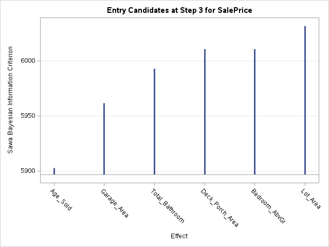

Stepwise Model Selection for SalePrice - BIC

The GLMSELECT Procedure

Stepwise Selection: Step 4

Effect Entered: Garage_Area

| Analysis of Variance Source | Analysis of Variance DF | Analysis of Variance Sum of Squares | Analysis of Variance Mean Square | Analysis of Variance F Value |
| --- | --- | --- | --- | --- |
| Model | 4 | 3.33571E11 | 83392754480 | 274.40 |
| Error | 295 | 89652501590 | 303906785 |  |
| Corrected Total | 299 | 4.232235E11 |  |  |

| Root MSE | 17433 |
| --- | --- |
| Dependent Mean | 137525 |
| R-Square | 0.7882 |
| Adj R-Sq | 0.7853 |
| AIC | 6166.62734 |
| AICC | 6166.91403 |
| BIC | 5865.82469 |
| C(p) | 35.73873 |
| SBC | 5883.14625 |

| Parameter Estimates Parameter | Parameter Estimates DF | Parameter Estimates Estimate | Parameter Estimates Standard Error | Parameter Estimates t Value |
| --- | --- | --- | --- | --- |
| Intercept | 1 | 43815 | 6023.907004 | 7.27 |
| Gr_Liv_Area | 1 | 61.238136 | 4.940722 | 12.39 |
| Basement_Area | 1 | 33.430181 | 3.363709 | 9.94 |
| Garage_Area | 1 | 42.984492 | 6.608851 | 6.50 |
| Age_Sold | 1 | -455.704354 | 42.173481 | -10.81 |

| Entry Candidates Rank | Entry Candidates Effect | Entry Candidates BIC |
| --- | --- | --- |
| 1 | Garage_Area | 5865.8247 |
| 2 | Deck_Porch_Area | 5882.8416 |
| 3 | Bedroom_AbvGr | 5892.4510 |
| 4 | Total_Bathroom | 5899.5016 |
| 5 | Lot_Area | 5899.8240 |

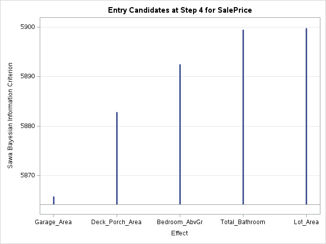

Stepwise Model Selection for SalePrice - BIC

The GLMSELECT Procedure

Stepwise Selection: Step 5

Effect Entered: Deck_Porch_Area

| Analysis of Variance Source | Analysis of Variance DF | Analysis of Variance Sum of Squares | Analysis of Variance Mean Square | Analysis of Variance F Value |
| --- | --- | --- | --- | --- |
| Model | 5 | 3.392788E11 | 67855752389 | 237.65 |
| Error | 294 | 83944757568 | 285526386 |  |
| Corrected Total | 299 | 4.232235E11 |  |  |

| Root MSE | 16898 |
| --- | --- |
| Dependent Mean | 137525 |
| R-Square | 0.8017 |
| Adj R-Sq | 0.7983 |
| AIC | 6148.89269 |
| AICC | 6149.27625 |
| BIC | 5848.69541 |
| C(p) | 17.00051 |
| SBC | 5869.11538 |

| Parameter Estimates Parameter | Parameter Estimates DF | Parameter Estimates Estimate | Parameter Estimates Standard Error | Parameter Estimates t Value |
| --- | --- | --- | --- | --- |
| Intercept | 1 | 46009 | 5859.485517 | 7.85 |
| Gr_Liv_Area | 1 | 58.386514 | 4.831268 | 12.09 |
| Basement_Area | 1 | 30.554240 | 3.323249 | 9.19 |
| Garage_Area | 1 | 40.158112 | 6.436997 | 6.24 |
| Deck_Porch_Area | 1 | 35.720258 | 7.989240 | 4.47 |
| Age_Sold | 1 | -447.254040 | 40.921927 | -10.93 |

| Entry Candidates Rank | Entry Candidates Effect | Entry Candidates BIC |
| --- | --- | --- |
| 1 | Deck_Porch_Area | 5848.6954 |
| 2 | Bedroom_AbvGr | 5858.1723 |
| 3 | Total_Bathroom | 5863.7094 |
| 4 | Lot_Area | 5865.5528 |

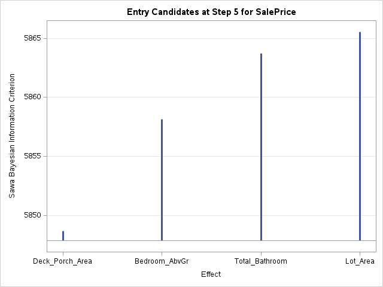

Stepwise Model Selection for SalePrice - BIC

The GLMSELECT Procedure

Stepwise Selection: Step 6

Effect Entered: Bedroom_AbvGr

| Analysis of Variance Source | Analysis of Variance DF | Analysis of Variance Sum of Squares | Analysis of Variance Mean Square | Analysis of Variance F Value |
| --- | --- | --- | --- | --- |
| Model | 6 | 3.410749E11 | 56845818595 | 202.75 |
| Error | 293 | 82148607939 | 280370676 |  |
| Corrected Total | 299 | 4.232235E11 |  |  |

| Root MSE | 16744 |
| --- | --- |
| Dependent Mean | 137525 |
| R-Square | 0.8059 |
| Adj R-Sq | 0.8019 |
| AIC | 6144.40398 |
| AICC | 6144.89882 |
| BIC | 5844.47548 |
| C(p) | 12.47448 |
| SBC | 5868.33046 |

| Parameter Estimates Parameter | Parameter Estimates DF | Parameter Estimates Estimate | Parameter Estimates Standard Error | Parameter Estimates t Value |
| --- | --- | --- | --- | --- |
| Intercept | 1 | 48620 | 5897.324643 | 8.24 |
| Gr_Liv_Area | 1 | 65.097413 | 5.472624 | 11.90 |
| Basement_Area | 1 | 31.279351 | 3.305546 | 9.46 |
| Garage_Area | 1 | 38.728785 | 6.403565 | 6.05 |
| Deck_Porch_Area | 1 | 32.487956 | 8.019119 | 4.05 |
| Age_Sold | 1 | -434.199118 | 40.877494 | -10.62 |
| Bedroom_AbvGr | 1 | -4189.095026 | 1655.065743 | -2.53 |

| Entry Candidates Rank | Entry Candidates Effect | Entry Candidates BIC |
| --- | --- | --- |
| 1 | Bedroom_AbvGr | 5844.4755 |
| 2 | Total_Bathroom | 5847.5999 |
| 3 | Lot_Area | 5848.2561 |

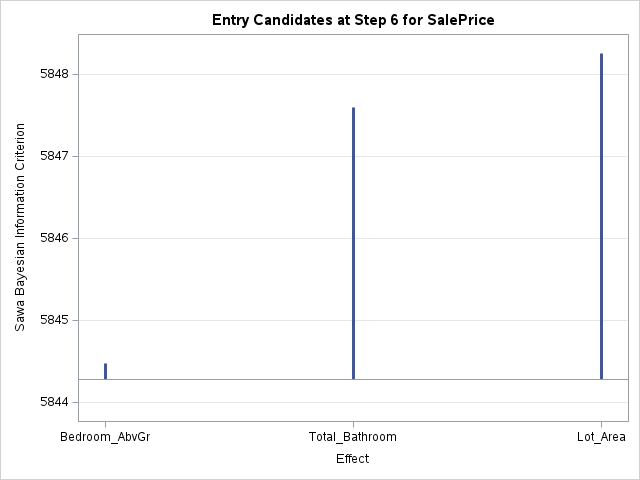

Stepwise Model Selection for SalePrice - BIC

The GLMSELECT Procedure

Stepwise Selection: Step 7

Effect Entered: Lot_Area

| Analysis of Variance Source | Analysis of Variance DF | Analysis of Variance Sum of Squares | Analysis of Variance Mean Square | Analysis of Variance F Value |
| --- | --- | --- | --- | --- |
| Model | 7 | 3.424508E11 | 48921543221 | 176.86 |
| Error | 292 | 80772716963 | 276618894 |  |
| Corrected Total | 299 | 4.232235E11 |  |  |

| Root MSE | 16632 |
| --- | --- |
| Dependent Mean | 137525 |
| R-Square | 0.8091 |
| Adj R-Sq | 0.8046 |
| AIC | 6141.33678 |
| AICC | 6141.95747 |
| BIC | 5841.69151 |
| C(p) | 9.47539 |
| SBC | 5868.96704 |

| Parameter Estimates Parameter | Parameter Estimates DF | Parameter Estimates Estimate | Parameter Estimates Standard Error | Parameter Estimates t Value |
| --- | --- | --- | --- | --- |
| Intercept | 1 | 47463 | 5880.674041 | 8.07 |
| Gr_Liv_Area | 1 | 65.303724 | 5.436672 | 12.01 |
| Basement_Area | 1 | 29.849078 | 3.345400 | 8.92 |
| Garage_Area | 1 | 36.309606 | 6.452405 | 5.63 |
| Deck_Porch_Area | 1 | 32.052554 | 7.967677 | 4.02 |
| Lot_Area | 1 | 0.708127 | 0.317512 | 2.23 |
| Age_Sold | 1 | -447.198682 | 41.019314 | -10.90 |
| Bedroom_AbvGr | 1 | -5042.766498 | 1687.928168 | -2.99 |

| Entry Candidates Rank | Entry Candidates Effect | Entry Candidates BIC |
| --- | --- | --- |
| 1 | Lot_Area | 5841.6915 |
| 2 | Total_Bathroom | 5844.0039 |

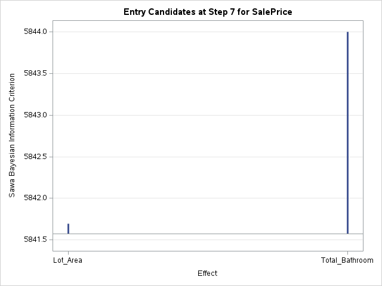

Stepwise Model Selection for SalePrice - BIC

The GLMSELECT Procedure

Stepwise Selection: Step 8

Effect Entered: Total_Bathroom

| Analysis of Variance Source | Analysis of Variance DF | Analysis of Variance Sum of Squares | Analysis of Variance Mean Square | Analysis of Variance F Value |
| --- | --- | --- | --- | --- |
| Model | 8 | 3.431321E11 | 42891512314 | 155.84 |
| Error | 291 | 80091420996 | 275228251 |  |
| Corrected Total | 299 | 4.232235E11 |  |  |

| Root MSE | 16590 |
| --- | --- |
| Dependent Mean | 137525 |
| R-Square | 0.8108 |
| Adj R-Sq | 0.8056 |
| AIC | 6140.79563 |
| AICC | 6141.55688 |
| BIC | 5841.35042 |
| C(p) | 9.00000 |
| SBC | 5872.12967 |

| Parameter Estimates Parameter | Parameter Estimates DF | Parameter Estimates Estimate | Parameter Estimates Standard Error | Parameter Estimates t Value |
| --- | --- | --- | --- | --- |
| Intercept | 1 | 44347 | 6191.271944 | 7.16 |
| Gr_Liv_Area | 1 | 63.197764 | 5.585739 | 11.31 |
| Basement_Area | 1 | 28.692184 | 3.417034 | 8.40 |
| Garage_Area | 1 | 35.754191 | 6.445840 | 5.55 |
| Deck_Porch_Area | 1 | 31.370539 | 7.959436 | 3.94 |
| Lot_Area | 1 | 0.699495 | 0.316761 | 2.21 |
| Age_Sold | 1 | -420.815037 | 44.219144 | -9.52 |
| Bedroom_AbvGr | 1 | -4834.848748 | 1688.858227 | -2.86 |
| Total_Bathroom | 1 | 3022.124723 | 1920.839066 | 1.57 |

| Entry Candidates Rank | Entry Candidates Effect | Entry Candidates BIC |
| --- | --- | --- |
| 1 | Total_Bathroom | 5841.3504 |

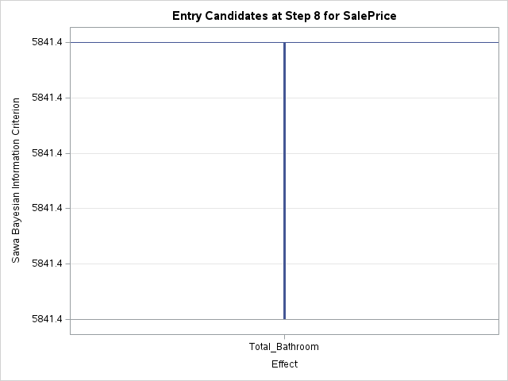

Stepwise Model Selection for SalePrice - BIC

The GLMSELECT Procedure

| Stepwise Selection Summary Step | Stepwise Selection Summary Effect Entered | Stepwise Selection Summary Effect Removed | Stepwise Selection Summary Number Effects In | Stepwise Selection Summary BIC |
| --- | --- | --- | --- | --- |
| 0 | Intercept |  | 1 | 6321.3096 |
| 1 | Basement_Area |  | 2 | 6129.3224 |
| 2 | Gr_Liv_Area |  | 3 | 6030.6866 |
| 3 | Age_Sold |  | 4 | 5903.1974 |
| 4 | Garage_Area |  | 5 | 5865.8247 |
| 5 | Deck_Porch_Area |  | 6 | 5848.6954 |
| 6 | Bedroom_AbvGr |  | 7 | 5844.4755 |
| 7 | Lot_Area |  | 8 | 5841.6915 |
| 8 | Total_Bathroom |  | 9 | 5841.3504* |

* Optimal Value of Criterion

| Selection stopped because all effects are in the final model. |
| --- |

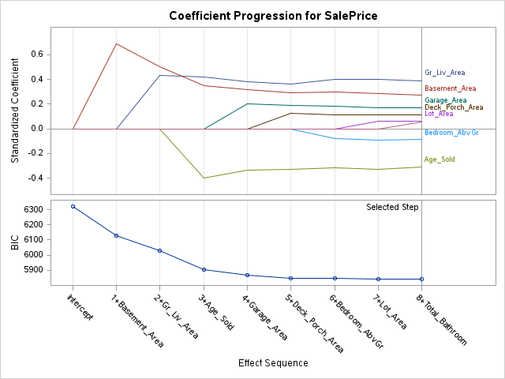

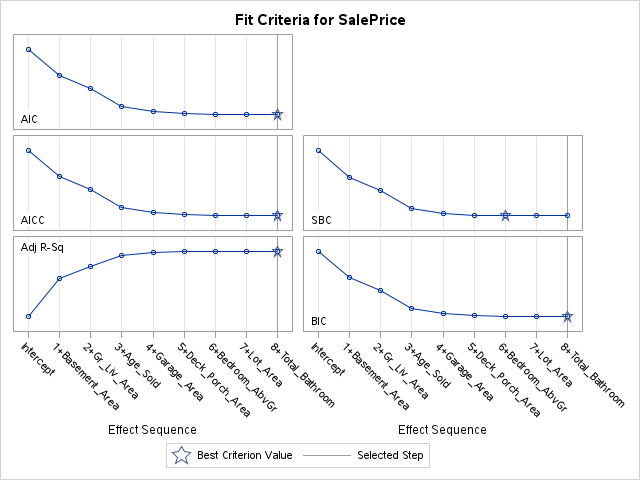

Stepwise Model Selection for SalePrice - BIC

The GLMSELECT Procedure

Selected Model

The selected model is the model at the last step (Step 8).

| Effects: | Intercept Gr_Liv_Area Basement_Area Garage_Area Deck_Porch_Area Lot_Area Age_Sold Bedroom_AbvGr Total_Bathroom |
| --- | --- |

| Analysis of Variance Source | Analysis of Variance DF | Analysis of Variance Sum of Squares | Analysis of Variance Mean Square | Analysis of Variance F Value |
| --- | --- | --- | --- | --- |
| Model | 8 | 3.431321E11 | 42891512314 | 155.84 |
| Error | 291 | 80091420996 | 275228251 |  |
| Corrected Total | 299 | 4.232235E11 |  |  |

| Root MSE | 16590 |
| --- | --- |
| Dependent Mean | 137525 |
| R-Square | 0.8108 |
| Adj R-Sq | 0.8056 |
| AIC | 6140.79563 |
| AICC | 6141.55688 |
| BIC | 5841.35042 |
| C(p) | 9.00000 |
| SBC | 5872.12967 |

| Parameter Estimates Parameter | Parameter Estimates DF | Parameter Estimates Estimate | Parameter Estimates Standard Error | Parameter Estimates t Value |
| --- | --- | --- | --- | --- |
| Intercept | 1 | 44347 | 6191.271944 | 7.16 |
| Gr_Liv_Area | 1 | 63.197764 | 5.585739 | 11.31 |
| Basement_Area | 1 | 28.692184 | 3.417034 | 8.40 |
| Garage_Area | 1 | 35.754191 | 6.445840 | 5.55 |
| Deck_Porch_Area | 1 | 31.370539 | 7.959436 | 3.94 |
| Lot_Area | 1 | 0.699495 | 0.316761 | 2.21 |
| Age_Sold | 1 | -420.815037 | 44.219144 | -9.52 |
| Bedroom_AbvGr | 1 | -4834.848748 | 1688.858227 | -2.86 |
| Total_Bathroom | 1 | 3022.124723 | 1920.839066 | 1.57 |

Stepwise Model Selection for SalePrice - AICC

The GLMSELECT Procedure

| Data Set | STAT1.AMESHOUSING3 |
| --- | --- |
| Dependent Variable | SalePrice |
| Selection Method | Stepwise |
| Select Criterion | AICC |
| Stop Criterion | AICC |
| Effect Hierarchy Enforced | None |

| Number of Observations Read | 300 |
| --- | --- |
| Number of Observations Used | 300 |

| Dimensions |  |
| --- | --- |
| Number of Effects | 9 |
| Number of Parameters | 9 |

Stepwise Model Selection for SalePrice - AICC

The GLMSELECT Procedure

Stepwise Selection: Step 0

Effect Entered: Intercept

| Analysis of Variance Source | Analysis of Variance DF | Analysis of Variance Sum of Squares | Analysis of Variance Mean Square | Analysis of Variance F Value |
| --- | --- | --- | --- | --- |
| Model | 0 | 0 | . | . |
| Error | 299 | 4.232235E11 | 1415463276 |  |
| Corrected Total | 299 | 4.232235E11 |  |  |

| Root MSE | 37623 |
| --- | --- |
| Dependent Mean | 137525 |
| R-Square | 0.0000 |
| Adj R-Sq | 0.0000 |
| AIC | 6624.21515 |
| AICC | 6624.25555 |
| SBC | 6325.91893 |

| Parameter Estimates Parameter | Parameter Estimates DF | Parameter Estimates Estimate | Parameter Estimates Standard Error | Parameter Estimates t Value |
| --- | --- | --- | --- | --- |
| Intercept | 1 | 137525 | 2172.144314 | 63.31 |

Stepwise Model Selection for SalePrice - AICC

The GLMSELECT Procedure

Stepwise Selection: Step 1

Effect Entered: Basement_Area

| Analysis of Variance Source | Analysis of Variance DF | Analysis of Variance Sum of Squares | Analysis of Variance Mean Square | Analysis of Variance F Value |
| --- | --- | --- | --- | --- |
| Model | 1 | 2.012418E11 | 2.012418E11 | 270.16 |
| Error | 298 | 2.219817E11 | 744904950 |  |
| Corrected Total | 299 | 4.232235E11 |  |  |

| Root MSE | 27293 |
| --- | --- |
| Dependent Mean | 137525 |
| R-Square | 0.4755 |
| Adj R-Sq | 0.4737 |
| AIC | 6432.62346 |
| AICC | 6432.70454 |
| SBC | 6138.03102 |

| Parameter Estimates Parameter | Parameter Estimates DF | Parameter Estimates Estimate | Parameter Estimates Standard Error | Parameter Estimates t Value |
| --- | --- | --- | --- | --- |
| Intercept | 1 | 73904 | 4179.193780 | 17.68 |
| Basement_Area | 1 | 72.107717 | 4.387055 | 16.44 |

| Entry Candidates Rank | Entry Candidates Effect | Entry Candidates AICC |
| --- | --- | --- |
| 1 | Basement_Area | 6432.7045 |
| 2 | Gr_Liv_Area | 6461.2688 |
| 3 | Age_Sold | 6483.4907 |
| 4 | Total_Bathroom | 6492.1679 |
| 5 | Garage_Area | 6503.8385 |
| 6 | Deck_Porch_Area | 6561.7799 |
| 7 | Lot_Area | 6606.3949 |
| 8 | Bedroom_AbvGr | 6617.9200 |

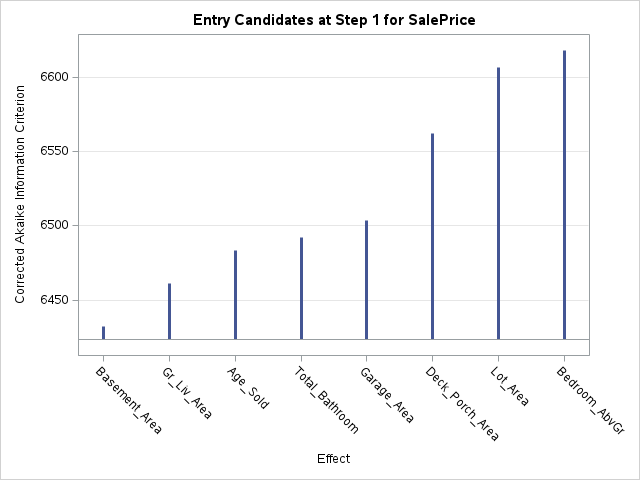

Stepwise Model Selection for SalePrice - AICC

The GLMSELECT Procedure

Stepwise Selection: Step 2

Effect Entered: Gr_Liv_Area

| Analysis of Variance Source | Analysis of Variance DF | Analysis of Variance Sum of Squares | Analysis of Variance Mean Square | Analysis of Variance F Value |
| --- | --- | --- | --- | --- |
| Model | 2 | 2.64483E11 | 1.322415E11 | 247.42 |
| Error | 297 | 1.587405E11 | 534479711 |  |
| Corrected Total | 299 | 4.232235E11 |  |  |

| Root MSE | 23119 |
| --- | --- |
| Dependent Mean | 137525 |
| R-Square | 0.6249 |
| Adj R-Sq | 0.6224 |
| AIC | 6334.02620 |
| AICC | 6334.16179 |
| SBC | 6043.13755 |

| Parameter Estimates Parameter | Parameter Estimates DF | Parameter Estimates Estimate | Parameter Estimates Standard Error | Parameter Estimates t Value |
| --- | --- | --- | --- | --- |
| Intercept | 1 | 12664 | 6650.339855 | 1.90 |
| Gr_Liv_Area | 1 | 69.606974 | 6.399091 | 10.88 |
| Basement_Area | 1 | 52.309702 | 4.137885 | 12.64 |

| Entry Candidates Rank | Entry Candidates Effect | Entry Candidates AICC |
| --- | --- | --- |
| 1 | Gr_Liv_Area | 6334.1618 |
| 2 | Age_Sold | 6342.1451 |
| 3 | Garage_Area | 6351.4417 |
| 4 | Total_Bathroom | 6376.5440 |
| 5 | Deck_Porch_Area | 6405.5828 |
| 6 | Lot_Area | 6432.0728 |
| 7 | Bedroom_AbvGr | 6434.2287 |

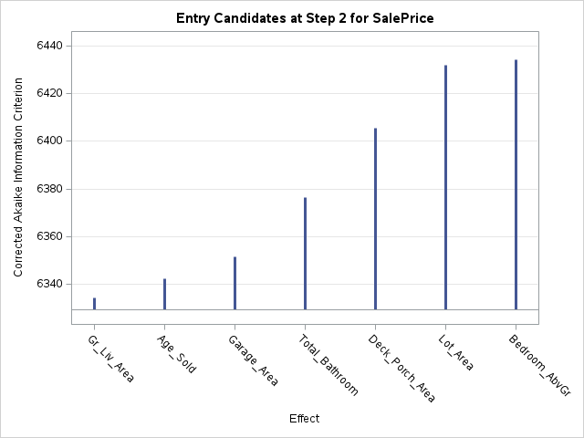

Stepwise Model Selection for SalePrice - AICC

The GLMSELECT Procedure

Stepwise Selection: Step 3

Effect Entered: Age_Sold

| Analysis of Variance Source | Analysis of Variance DF | Analysis of Variance Sum of Squares | Analysis of Variance Mean Square | Analysis of Variance F Value |
| --- | --- | --- | --- | --- |
| Model | 3 | 3.207148E11 | 1.069049E11 | 308.69 |
| Error | 296 | 1.025087E11 | 346313132 |  |
| Corrected Total | 299 | 4.232235E11 |  |  |

| Root MSE | 18609 |
| --- | --- |
| Dependent Mean | 137525 |
| R-Square | 0.7578 |
| Adj R-Sq | 0.7553 |
| AIC | 6204.82927 |
| AICC | 6205.03335 |
| SBC | 5917.64440 |

| Parameter Estimates Parameter | Parameter Estimates DF | Parameter Estimates Estimate | Parameter Estimates Standard Error | Parameter Estimates t Value |
| --- | --- | --- | --- | --- |
| Intercept | 1 | 53400 | 6235.076995 | 8.56 |
| Gr_Liv_Area | 1 | 68.106646 | 5.152294 | 13.22 |
| Basement_Area | 1 | 36.329120 | 3.559067 | 10.21 |
| Age_Sold | 1 | -543.493346 | 42.651840 | -12.74 |

| Entry Candidates Rank | Entry Candidates Effect | Entry Candidates AICC |
| --- | --- | --- |
| 1 | Age_Sold | 6205.0334 |
| 2 | Garage_Area | 6264.8697 |
| 3 | Total_Bathroom | 6296.5482 |
| 4 | Deck_Porch_Area | 6314.4852 |
| 5 | Bedroom_AbvGr | 6314.6119 |
| 6 | Lot_Area | 6336.0030 |

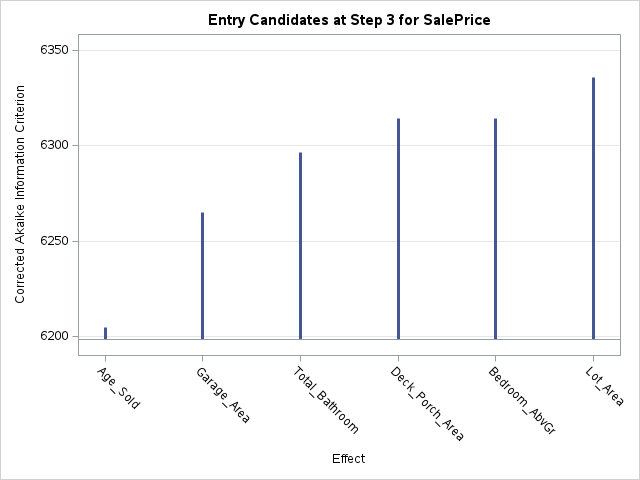

Stepwise Model Selection for SalePrice - AICC

The GLMSELECT Procedure

Stepwise Selection: Step 4

Effect Entered: Garage_Area

| Analysis of Variance Source | Analysis of Variance DF | Analysis of Variance Sum of Squares | Analysis of Variance Mean Square | Analysis of Variance F Value |
| --- | --- | --- | --- | --- |
| Model | 4 | 3.33571E11 | 83392754480 | 274.40 |
| Error | 295 | 89652501590 | 303906785 |  |
| Corrected Total | 299 | 4.232235E11 |  |  |

| Root MSE | 17433 |
| --- | --- |
| Dependent Mean | 137525 |
| R-Square | 0.7882 |
| Adj R-Sq | 0.7853 |
| AIC | 6166.62734 |
| AICC | 6166.91403 |
| SBC | 5883.14625 |

| Parameter Estimates Parameter | Parameter Estimates DF | Parameter Estimates Estimate | Parameter Estimates Standard Error | Parameter Estimates t Value |
| --- | --- | --- | --- | --- |
| Intercept | 1 | 43815 | 6023.907004 | 7.27 |
| Gr_Liv_Area | 1 | 61.238136 | 4.940722 | 12.39 |
| Basement_Area | 1 | 33.430181 | 3.363709 | 9.94 |
| Garage_Area | 1 | 42.984492 | 6.608851 | 6.50 |
| Age_Sold | 1 | -455.704354 | 42.173481 | -10.81 |

| Entry Candidates Rank | Entry Candidates Effect | Entry Candidates AICC |
| --- | --- | --- |
| 1 | Garage_Area | 6166.9140 |
| 2 | Deck_Porch_Area | 6184.4767 |
| 3 | Bedroom_AbvGr | 6194.3847 |
| 4 | Total_Bathroom | 6201.6500 |
| 5 | Lot_Area | 6201.9821 |

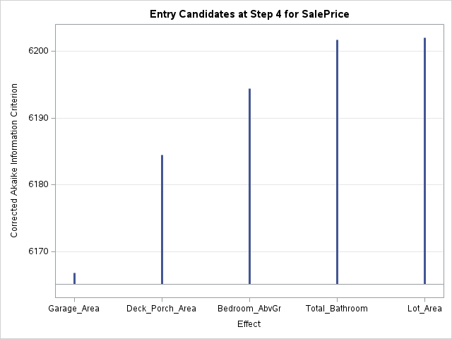

Stepwise Model Selection for SalePrice - AICC

The GLMSELECT Procedure

Stepwise Selection: Step 5

Effect Entered: Deck_Porch_Area

| Analysis of Variance Source | Analysis of Variance DF | Analysis of Variance Sum of Squares | Analysis of Variance Mean Square | Analysis of Variance F Value |
| --- | --- | --- | --- | --- |
| Model | 5 | 3.392788E11 | 67855752389 | 237.65 |
| Error | 294 | 83944757568 | 285526386 |  |
| Corrected Total | 299 | 4.232235E11 |  |  |

| Root MSE | 16898 |
| --- | --- |
| Dependent Mean | 137525 |
| R-Square | 0.8017 |
| Adj R-Sq | 0.7983 |
| AIC | 6148.89269 |
| AICC | 6149.27625 |
| SBC | 5869.11538 |

| Parameter Estimates Parameter | Parameter Estimates DF | Parameter Estimates Estimate | Parameter Estimates Standard Error | Parameter Estimates t Value |
| --- | --- | --- | --- | --- |
| Intercept | 1 | 46009 | 5859.485517 | 7.85 |
| Gr_Liv_Area | 1 | 58.386514 | 4.831268 | 12.09 |
| Basement_Area | 1 | 30.554240 | 3.323249 | 9.19 |
| Garage_Area | 1 | 40.158112 | 6.436997 | 6.24 |
| Deck_Porch_Area | 1 | 35.720258 | 7.989240 | 4.47 |
| Age_Sold | 1 | -447.254040 | 40.921927 | -10.93 |

| Entry Candidates Rank | Entry Candidates Effect | Entry Candidates AICC |
| --- | --- | --- |
| 1 | Deck_Porch_Area | 6149.2763 |
| 2 | Bedroom_AbvGr | 6159.1390 |
| 3 | Total_Bathroom | 6164.8974 |
| 4 | Lot_Area | 6166.8138 |

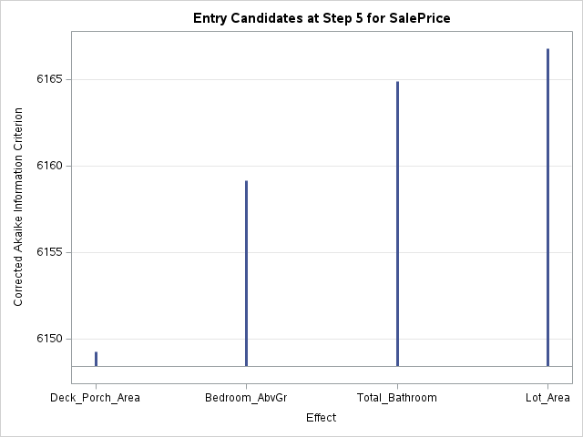

Stepwise Model Selection for SalePrice - AICC

The GLMSELECT Procedure

Stepwise Selection: Step 6

Effect Entered: Bedroom_AbvGr

| Analysis of Variance Source | Analysis of Variance DF | Analysis of Variance Sum of Squares | Analysis of Variance Mean Square | Analysis of Variance F Value |
| --- | --- | --- | --- | --- |
| Model | 6 | 3.410749E11 | 56845818595 | 202.75 |
| Error | 293 | 82148607939 | 280370676 |  |
| Corrected Total | 299 | 4.232235E11 |  |  |

| Root MSE | 16744 |
| --- | --- |
| Dependent Mean | 137525 |
| R-Square | 0.8059 |
| Adj R-Sq | 0.8019 |
| AIC | 6144.40398 |
| AICC | 6144.89882 |
| SBC | 5868.33046 |

| Parameter Estimates Parameter | Parameter Estimates DF | Parameter Estimates Estimate | Parameter Estimates Standard Error | Parameter Estimates t Value |
| --- | --- | --- | --- | --- |
| Intercept | 1 | 48620 | 5897.324643 | 8.24 |
| Gr_Liv_Area | 1 | 65.097413 | 5.472624 | 11.90 |
| Basement_Area | 1 | 31.279351 | 3.305546 | 9.46 |
| Garage_Area | 1 | 38.728785 | 6.403565 | 6.05 |
| Deck_Porch_Area | 1 | 32.487956 | 8.019119 | 4.05 |
| Age_Sold | 1 | -434.199118 | 40.877494 | -10.62 |
| Bedroom_AbvGr | 1 | -4189.095026 | 1655.065743 | -2.53 |

| Entry Candidates Rank | Entry Candidates Effect | Entry Candidates AICC |
| --- | --- | --- |
| 1 | Bedroom_AbvGr | 6144.8988 |
| 2 | Total_Bathroom | 6148.1761 |
| 3 | Lot_Area | 6148.8642 |

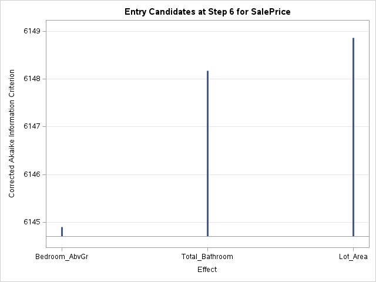

Stepwise Model Selection for SalePrice - AICC

The GLMSELECT Procedure

Stepwise Selection: Step 7

Effect Entered: Lot_Area

| Analysis of Variance Source | Analysis of Variance DF | Analysis of Variance Sum of Squares | Analysis of Variance Mean Square | Analysis of Variance F Value |
| --- | --- | --- | --- | --- |
| Model | 7 | 3.424508E11 | 48921543221 | 176.86 |
| Error | 292 | 80772716963 | 276618894 |  |
| Corrected Total | 299 | 4.232235E11 |  |  |

| Root MSE | 16632 |
| --- | --- |
| Dependent Mean | 137525 |
| R-Square | 0.8091 |
| Adj R-Sq | 0.8046 |
| AIC | 6141.33678 |
| AICC | 6141.95747 |
| SBC | 5868.96704 |

| Parameter Estimates Parameter | Parameter Estimates DF | Parameter Estimates Estimate | Parameter Estimates Standard Error | Parameter Estimates t Value |
| --- | --- | --- | --- | --- |
| Intercept | 1 | 47463 | 5880.674041 | 8.07 |
| Gr_Liv_Area | 1 | 65.303724 | 5.436672 | 12.01 |
| Basement_Area | 1 | 29.849078 | 3.345400 | 8.92 |
| Garage_Area | 1 | 36.309606 | 6.452405 | 5.63 |
| Deck_Porch_Area | 1 | 32.052554 | 7.967677 | 4.02 |
| Lot_Area | 1 | 0.708127 | 0.317512 | 2.23 |
| Age_Sold | 1 | -447.198682 | 41.019314 | -10.90 |
| Bedroom_AbvGr | 1 | -5042.766498 | 1687.928168 | -2.99 |

| Entry Candidates Rank | Entry Candidates Effect | Entry Candidates AICC |
| --- | --- | --- |
| 1 | Lot_Area | 6141.9575 |
| 2 | Total_Bathroom | 6144.4020 |

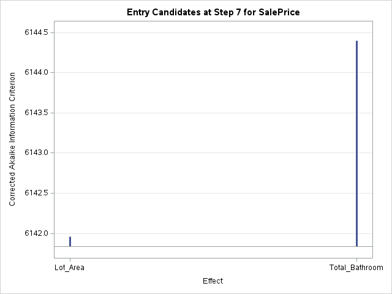

Stepwise Model Selection for SalePrice - AICC

The GLMSELECT Procedure

Stepwise Selection: Step 8

Effect Entered: Total_Bathroom

| Analysis of Variance Source | Analysis of Variance DF | Analysis of Variance Sum of Squares | Analysis of Variance Mean Square | Analysis of Variance F Value |
| --- | --- | --- | --- | --- |
| Model | 8 | 3.431321E11 | 42891512314 | 155.84 |
| Error | 291 | 80091420996 | 275228251 |  |
| Corrected Total | 299 | 4.232235E11 |  |  |

| Root MSE | 16590 |
| --- | --- |
| Dependent Mean | 137525 |
| R-Square | 0.8108 |
| Adj R-Sq | 0.8056 |
| AIC | 6140.79563 |
| AICC | 6141.55688 |
| SBC | 5872.12967 |

| Parameter Estimates Parameter | Parameter Estimates DF | Parameter Estimates Estimate | Parameter Estimates Standard Error | Parameter Estimates t Value |
| --- | --- | --- | --- | --- |
| Intercept | 1 | 44347 | 6191.271944 | 7.16 |
| Gr_Liv_Area | 1 | 63.197764 | 5.585739 | 11.31 |
| Basement_Area | 1 | 28.692184 | 3.417034 | 8.40 |
| Garage_Area | 1 | 35.754191 | 6.445840 | 5.55 |
| Deck_Porch_Area | 1 | 31.370539 | 7.959436 | 3.94 |
| Lot_Area | 1 | 0.699495 | 0.316761 | 2.21 |
| Age_Sold | 1 | -420.815037 | 44.219144 | -9.52 |
| Bedroom_AbvGr | 1 | -4834.848748 | 1688.858227 | -2.86 |
| Total_Bathroom | 1 | 3022.124723 | 1920.839066 | 1.57 |

| Entry Candidates Rank | Entry Candidates Effect | Entry Candidates AICC |
| --- | --- | --- |
| 1 | Total_Bathroom | 6141.5569 |

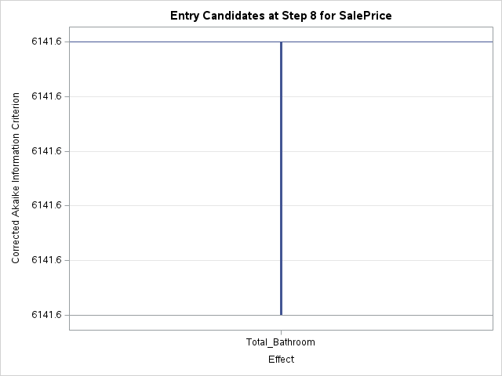

Stepwise Model Selection for SalePrice - AICC

The GLMSELECT Procedure

| Stepwise Selection Summary Step | Stepwise Selection Summary Effect Entered | Stepwise Selection Summary Effect Removed | Stepwise Selection Summary Number Effects In | Stepwise Selection Summary AICC |
| --- | --- | --- | --- | --- |
| 0 | Intercept |  | 1 | 6624.2555 |
| 1 | Basement_Area |  | 2 | 6432.7045 |
| 2 | Gr_Liv_Area |  | 3 | 6334.1618 |
| 3 | Age_Sold |  | 4 | 6205.0334 |
| 4 | Garage_Area |  | 5 | 6166.9140 |
| 5 | Deck_Porch_Area |  | 6 | 6149.2763 |
| 6 | Bedroom_AbvGr |  | 7 | 6144.8988 |
| 7 | Lot_Area |  | 8 | 6141.9575 |
| 8 | Total_Bathroom |  | 9 | 6141.5569* |

* Optimal Value of Criterion

| Selection stopped because all effects are in the final model. |
| --- |

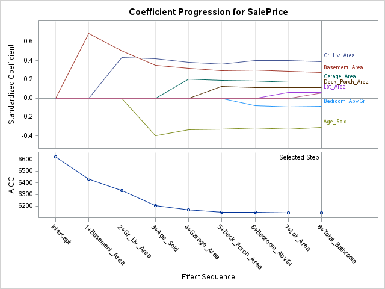

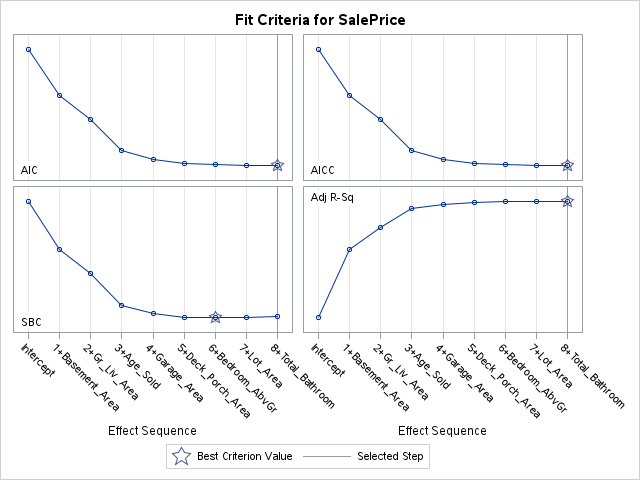

Stepwise Model Selection for SalePrice - AICC

The GLMSELECT Procedure

Selected Model

The selected model is the model at the last step (Step 8).

| Effects: | Intercept Gr_Liv_Area Basement_Area Garage_Area Deck_Porch_Area Lot_Area Age_Sold Bedroom_AbvGr Total_Bathroom |
| --- | --- |

| Analysis of Variance Source | Analysis of Variance DF | Analysis of Variance Sum of Squares | Analysis of Variance Mean Square | Analysis of Variance F Value |
| --- | --- | --- | --- | --- |
| Model | 8 | 3.431321E11 | 42891512314 | 155.84 |
| Error | 291 | 80091420996 | 275228251 |  |
| Corrected Total | 299 | 4.232235E11 |  |  |

| Root MSE | 16590 |
| --- | --- |
| Dependent Mean | 137525 |
| R-Square | 0.8108 |
| Adj R-Sq | 0.8056 |
| AIC | 6140.79563 |
| AICC | 6141.55688 |
| SBC | 5872.12967 |

| Parameter Estimates Parameter | Parameter Estimates DF | Parameter Estimates Estimate | Parameter Estimates Standard Error | Parameter Estimates t Value |
| --- | --- | --- | --- | --- |
| Intercept | 1 | 44347 | 6191.271944 | 7.16 |
| Gr_Liv_Area | 1 | 63.197764 | 5.585739 | 11.31 |
| Basement_Area | 1 | 28.692184 | 3.417034 | 8.40 |
| Garage_Area | 1 | 35.754191 | 6.445840 | 5.55 |
| Deck_Porch_Area | 1 | 31.370539 | 7.959436 | 3.94 |
| Lot_Area | 1 | 0.699495 | 0.316761 | 2.21 |
| Age_Sold | 1 | -420.815037 | 44.219144 | -9.52 |
| Bedroom_AbvGr | 1 | -4834.848748 | 1688.858227 | -2.86 |
| Total_Bathroom | 1 | 3022.124723 | 1920.839066 | 1.57 |

Stepwise Model Selection for SalePrice - SBC

The GLMSELECT Procedure

| Data Set | STAT1.AMESHOUSING3 |
| --- | --- |
| Dependent Variable | SalePrice |
| Selection Method | Stepwise |
| Select Criterion | SBC |
| Stop Criterion | SBC |
| Effect Hierarchy Enforced | None |

| Number of Observations Read | 300 |
| --- | --- |
| Number of Observations Used | 300 |

| Dimensions |  |
| --- | --- |
| Number of Effects | 9 |
| Number of Parameters | 9 |

Stepwise Model Selection for SalePrice - SBC

The GLMSELECT Procedure

Stepwise Selection: Step 0

Effect Entered: Intercept

| Analysis of Variance Source | Analysis of Variance DF | Analysis of Variance Sum of Squares | Analysis of Variance Mean Square | Analysis of Variance F Value |
| --- | --- | --- | --- | --- |
| Model | 0 | 0 | . | . |
| Error | 299 | 4.232235E11 | 1415463276 |  |
| Corrected Total | 299 | 4.232235E11 |  |  |

| Root MSE | 37623 |
| --- | --- |
| Dependent Mean | 137525 |
| R-Square | 0.0000 |
| Adj R-Sq | 0.0000 |
| AIC | 6624.21515 |
| AICC | 6624.25555 |
| SBC | 6325.91893 |

| Parameter Estimates Parameter | Parameter Estimates DF | Parameter Estimates Estimate | Parameter Estimates Standard Error | Parameter Estimates t Value |
| --- | --- | --- | --- | --- |
| Intercept | 1 | 137525 | 2172.144314 | 63.31 |

Stepwise Model Selection for SalePrice - SBC

The GLMSELECT Procedure

Stepwise Selection: Step 1

Effect Entered: Basement_Area

| Analysis of Variance Source | Analysis of Variance DF | Analysis of Variance Sum of Squares | Analysis of Variance Mean Square | Analysis of Variance F Value |
| --- | --- | --- | --- | --- |
| Model | 1 | 2.012418E11 | 2.012418E11 | 270.16 |
| Error | 298 | 2.219817E11 | 744904950 |  |
| Corrected Total | 299 | 4.232235E11 |  |  |

| Root MSE | 27293 |
| --- | --- |
| Dependent Mean | 137525 |
| R-Square | 0.4755 |
| Adj R-Sq | 0.4737 |
| AIC | 6432.62346 |
| AICC | 6432.70454 |
| SBC | 6138.03102 |

| Parameter Estimates Parameter | Parameter Estimates DF | Parameter Estimates Estimate | Parameter Estimates Standard Error | Parameter Estimates t Value |
| --- | --- | --- | --- | --- |
| Intercept | 1 | 73904 | 4179.193780 | 17.68 |
| Basement_Area | 1 | 72.107717 | 4.387055 | 16.44 |

| Entry Candidates Rank | Entry Candidates Effect | Entry Candidates SBC |
| --- | --- | --- |
| 1 | Basement_Area | 6138.0310 |
| 2 | Gr_Liv_Area | 6166.5953 |
| 3 | Age_Sold | 6188.8172 |
| 4 | Total_Bathroom | 6197.4944 |
| 5 | Garage_Area | 6209.1649 |
| 6 | Deck_Porch_Area | 6267.1064 |
| 7 | Lot_Area | 6311.7214 |
| 8 | Bedroom_AbvGr | 6323.2465 |

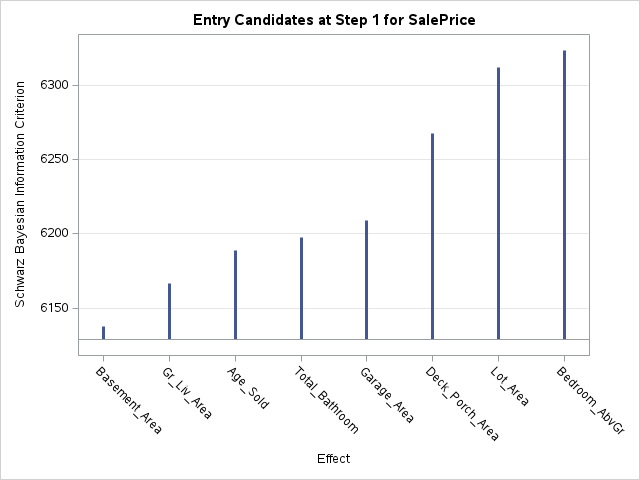

Stepwise Model Selection for SalePrice - SBC

The GLMSELECT Procedure

Stepwise Selection: Step 2

Effect Entered: Gr_Liv_Area

| Analysis of Variance Source | Analysis of Variance DF | Analysis of Variance Sum of Squares | Analysis of Variance Mean Square | Analysis of Variance F Value |
| --- | --- | --- | --- | --- |
| Model | 2 | 2.64483E11 | 1.322415E11 | 247.42 |
| Error | 297 | 1.587405E11 | 534479711 |  |
| Corrected Total | 299 | 4.232235E11 |  |  |

| Root MSE | 23119 |
| --- | --- |
| Dependent Mean | 137525 |
| R-Square | 0.6249 |
| Adj R-Sq | 0.6224 |
| AIC | 6334.02620 |
| AICC | 6334.16179 |
| SBC | 6043.13755 |

| Parameter Estimates Parameter | Parameter Estimates DF | Parameter Estimates Estimate | Parameter Estimates Standard Error | Parameter Estimates t Value |
| --- | --- | --- | --- | --- |
| Intercept | 1 | 12664 | 6650.339855 | 1.90 |
| Gr_Liv_Area | 1 | 69.606974 | 6.399091 | 10.88 |
| Basement_Area | 1 | 52.309702 | 4.137885 | 12.64 |

| Entry Candidates Rank | Entry Candidates Effect | Entry Candidates SBC |
| --- | --- | --- |
| 1 | Gr_Liv_Area | 6043.1375 |
| 2 | Age_Sold | 6051.1208 |
| 3 | Garage_Area | 6060.4174 |
| 4 | Total_Bathroom | 6085.5197 |
| 5 | Deck_Porch_Area | 6114.5586 |
| 6 | Lot_Area | 6141.0486 |
| 7 | Bedroom_AbvGr | 6143.2044 |

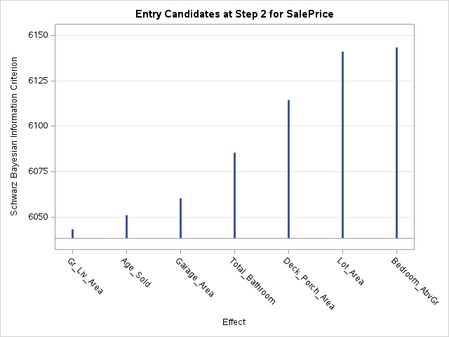

Stepwise Model Selection for SalePrice - SBC

The GLMSELECT Procedure

Stepwise Selection: Step 3

Effect Entered: Age_Sold

| Analysis of Variance Source | Analysis of Variance DF | Analysis of Variance Sum of Squares | Analysis of Variance Mean Square | Analysis of Variance F Value |
| --- | --- | --- | --- | --- |
| Model | 3 | 3.207148E11 | 1.069049E11 | 308.69 |
| Error | 296 | 1.025087E11 | 346313132 |  |
| Corrected Total | 299 | 4.232235E11 |  |  |

| Root MSE | 18609 |
| --- | --- |
| Dependent Mean | 137525 |
| R-Square | 0.7578 |
| Adj R-Sq | 0.7553 |
| AIC | 6204.82927 |
| AICC | 6205.03335 |
| SBC | 5917.64440 |

| Parameter Estimates Parameter | Parameter Estimates DF | Parameter Estimates Estimate | Parameter Estimates Standard Error | Parameter Estimates t Value |
| --- | --- | --- | --- | --- |
| Intercept | 1 | 53400 | 6235.076995 | 8.56 |
| Gr_Liv_Area | 1 | 68.106646 | 5.152294 | 13.22 |
| Basement_Area | 1 | 36.329120 | 3.559067 | 10.21 |
| Age_Sold | 1 | -543.493346 | 42.651840 | -12.74 |

| Entry Candidates Rank | Entry Candidates Effect | Entry Candidates SBC |
| --- | --- | --- |
| 1 | Age_Sold | 5917.6444 |
| 2 | Garage_Area | 5977.4808 |
| 3 | Total_Bathroom | 6009.1592 |
| 4 | Deck_Porch_Area | 6027.0962 |
| 5 | Bedroom_AbvGr | 6027.2230 |
| 6 | Lot_Area | 6048.6141 |

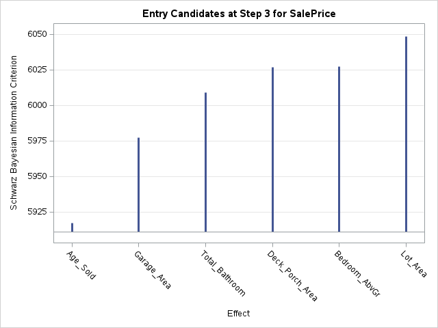

Stepwise Model Selection for SalePrice - SBC

The GLMSELECT Procedure

Stepwise Selection: Step 4

Effect Entered: Garage_Area

| Analysis of Variance Source | Analysis of Variance DF | Analysis of Variance Sum of Squares | Analysis of Variance Mean Square | Analysis of Variance F Value |
| --- | --- | --- | --- | --- |
| Model | 4 | 3.33571E11 | 83392754480 | 274.40 |
| Error | 295 | 89652501590 | 303906785 |  |
| Corrected Total | 299 | 4.232235E11 |  |  |

| Root MSE | 17433 |
| --- | --- |
| Dependent Mean | 137525 |
| R-Square | 0.7882 |
| Adj R-Sq | 0.7853 |
| AIC | 6166.62734 |
| AICC | 6166.91403 |
| SBC | 5883.14625 |

| Parameter Estimates Parameter | Parameter Estimates DF | Parameter Estimates Estimate | Parameter Estimates Standard Error | Parameter Estimates t Value |
| --- | --- | --- | --- | --- |
| Intercept | 1 | 43815 | 6023.907004 | 7.27 |
| Gr_Liv_Area | 1 | 61.238136 | 4.940722 | 12.39 |
| Basement_Area | 1 | 33.430181 | 3.363709 | 9.94 |
| Garage_Area | 1 | 42.984492 | 6.608851 | 6.50 |
| Age_Sold | 1 | -455.704354 | 42.173481 | -10.81 |

| Entry Candidates Rank | Entry Candidates Effect | Entry Candidates SBC |
| --- | --- | --- |
| 1 | Garage_Area | 5883.1463 |
| 2 | Deck_Porch_Area | 5900.7089 |
| 3 | Bedroom_AbvGr | 5910.6169 |
| 4 | Total_Bathroom | 5917.8822 |
| 5 | Lot_Area | 5918.2143 |

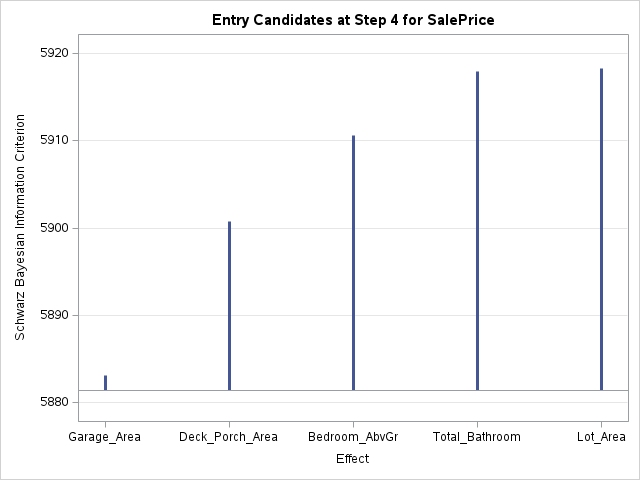

Stepwise Model Selection for SalePrice - SBC

The GLMSELECT Procedure

Stepwise Selection: Step 5

Effect Entered: Deck_Porch_Area

| Analysis of Variance Source | Analysis of Variance DF | Analysis of Variance Sum of Squares | Analysis of Variance Mean Square | Analysis of Variance F Value |
| --- | --- | --- | --- | --- |
| Model | 5 | 3.392788E11 | 67855752389 | 237.65 |
| Error | 294 | 83944757568 | 285526386 |  |
| Corrected Total | 299 | 4.232235E11 |  |  |

| Root MSE | 16898 |
| --- | --- |
| Dependent Mean | 137525 |
| R-Square | 0.8017 |
| Adj R-Sq | 0.7983 |
| AIC | 6148.89269 |
| AICC | 6149.27625 |
| SBC | 5869.11538 |

| Parameter Estimates Parameter | Parameter Estimates DF | Parameter Estimates Estimate | Parameter Estimates Standard Error | Parameter Estimates t Value |
| --- | --- | --- | --- | --- |
| Intercept | 1 | 46009 | 5859.485517 | 7.85 |
| Gr_Liv_Area | 1 | 58.386514 | 4.831268 | 12.09 |
| Basement_Area | 1 | 30.554240 | 3.323249 | 9.19 |
| Garage_Area | 1 | 40.158112 | 6.436997 | 6.24 |
| Deck_Porch_Area | 1 | 35.720258 | 7.989240 | 4.47 |
| Age_Sold | 1 | -447.254040 | 40.921927 | -10.93 |

| Entry Candidates Rank | Entry Candidates Effect | Entry Candidates SBC |
| --- | --- | --- |
| 1 | Deck_Porch_Area | 5869.1154 |
| 2 | Bedroom_AbvGr | 5878.9781 |
| 3 | Total_Bathroom | 5884.7365 |
| 4 | Lot_Area | 5886.6529 |

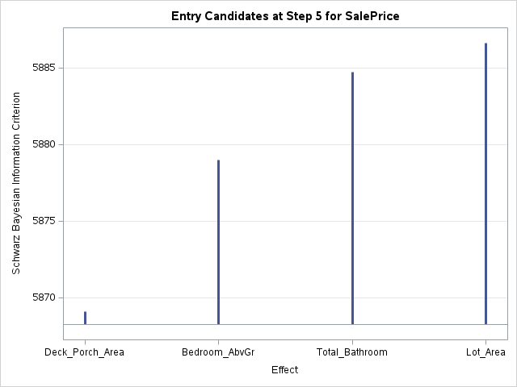

Stepwise Model Selection for SalePrice - SBC

The GLMSELECT Procedure

Stepwise Selection: Step 6

Effect Entered: Bedroom_AbvGr

| Analysis of Variance Source | Analysis of Variance DF | Analysis of Variance Sum of Squares | Analysis of Variance Mean Square | Analysis of Variance F Value |
| --- | --- | --- | --- | --- |
| Model | 6 | 3.410749E11 | 56845818595 | 202.75 |
| Error | 293 | 82148607939 | 280370676 |  |
| Corrected Total | 299 | 4.232235E11 |  |  |

| Root MSE | 16744 |
| --- | --- |
| Dependent Mean | 137525 |
| R-Square | 0.8059 |
| Adj R-Sq | 0.8019 |
| AIC | 6144.40398 |
| AICC | 6144.89882 |
| SBC | 5868.33046 |

| Parameter Estimates Parameter | Parameter Estimates DF | Parameter Estimates Estimate | Parameter Estimates Standard Error | Parameter Estimates t Value |
| --- | --- | --- | --- | --- |
| Intercept | 1 | 48620 | 5897.324643 | 8.24 |
| Gr_Liv_Area | 1 | 65.097413 | 5.472624 | 11.90 |
| Basement_Area | 1 | 31.279351 | 3.305546 | 9.46 |
| Garage_Area | 1 | 38.728785 | 6.403565 | 6.05 |
| Deck_Porch_Area | 1 | 32.487956 | 8.019119 | 4.05 |
| Age_Sold | 1 | -434.199118 | 40.877494 | -10.62 |
| Bedroom_AbvGr | 1 | -4189.095026 | 1655.065743 | -2.53 |

| Entry Candidates Rank | Entry Candidates Effect | Entry Candidates SBC |
| --- | --- | --- |
| 1 | Bedroom_AbvGr | 5868.3305 |
| 2 | Total_Bathroom | 5871.6077 |
| 3 | Lot_Area | 5872.2959 |

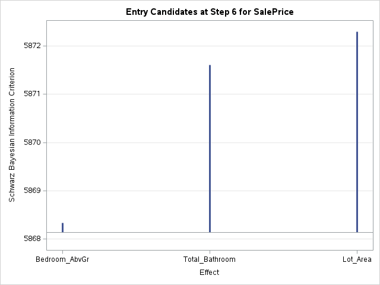

Stepwise Model Selection for SalePrice - SBC

The GLMSELECT Procedure

| Stepwise Selection Summary Step | Stepwise Selection Summary Effect Entered | Stepwise Selection Summary Effect Removed | Stepwise Selection Summary Number Effects In | Stepwise Selection Summary SBC |
| --- | --- | --- | --- | --- |
| 0 | Intercept |  | 1 | 6325.9189 |
| 1 | Basement_Area |  | 2 | 6138.0310 |
| 2 | Gr_Liv_Area |  | 3 | 6043.1375 |
| 3 | Age_Sold |  | 4 | 5917.6444 |
| 4 | Garage_Area |  | 5 | 5883.1463 |
| 5 | Deck_Porch_Area |  | 6 | 5869.1154 |
| 6 | Bedroom_AbvGr |  | 7 | 5868.3305* |

* Optimal Value of Criterion

| Selection stopped at a local minimum of the SBC criterion. |
| --- |

| Stop Details Candidate For | Stop Details Effect | Stop Details Candidate SBC | Stop Details | Stop Details Compare SBC |
| --- | --- | --- | --- | --- |
| Entry | Lot_Area | 5868.9670 | > | 5868.3305 |
| Removal | Bedroom_AbvGr | 5869.1154 | > | 5868.3305 |

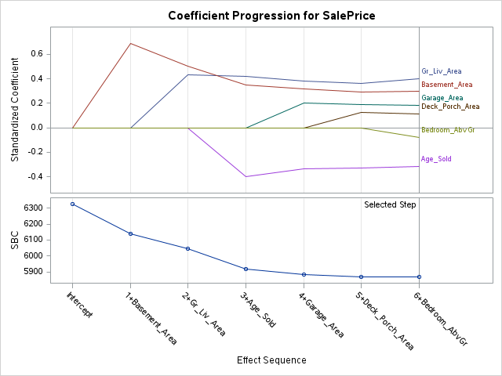

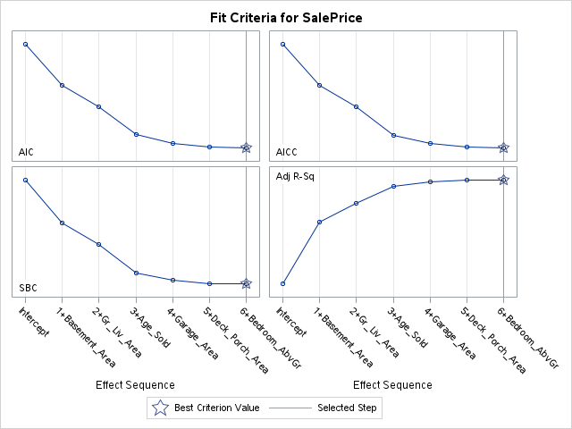

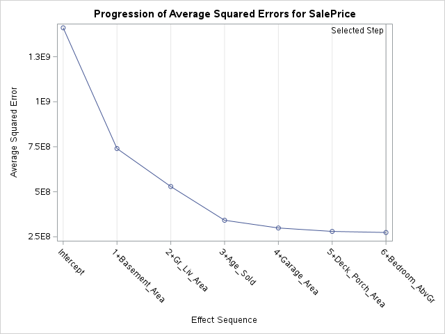

Stepwise Model Selection for SalePrice - SBC

The GLMSELECT Procedure

Selected Model

The selected model is the model at the last step (Step 6).

| Effects: | Intercept Gr_Liv_Area Basement_Area Garage_Area Deck_Porch_Area Age_Sold Bedroom_AbvGr |
| --- | --- |

| Analysis of Variance Source | Analysis of Variance DF | Analysis of Variance Sum of Squares | Analysis of Variance Mean Square | Analysis of Variance F Value |
| --- | --- | --- | --- | --- |
| Model | 6 | 3.410749E11 | 56845818595 | 202.75 |
| Error | 293 | 82148607939 | 280370676 |  |
| Corrected Total | 299 | 4.232235E11 |  |  |

| Root MSE | 16744 |
| --- | --- |
| Dependent Mean | 137525 |
| R-Square | 0.8059 |
| Adj R-Sq | 0.8019 |
| AIC | 6144.40398 |
| AICC | 6144.89882 |
| SBC | 5868.33046 |

| Parameter Estimates Parameter | Parameter Estimates DF | Parameter Estimates Estimate | Parameter Estimates Standard Error | Parameter Estimates t Value |
| --- | --- | --- | --- | --- |
| Intercept | 1 | 48620 | 5897.324643 | 8.24 |
| Gr_Liv_Area | 1 | 65.097413 | 5.472624 | 11.90 |
| Basement_Area | 1 | 31.279351 | 3.305546 | 9.46 |
| Garage_Area | 1 | 38.728785 | 6.403565 | 6.05 |
| Deck_Porch_Area | 1 | 32.487956 | 8.019119 | 4.05 |
| Age_Sold | 1 | -434.199118 | 40.877494 | -10.62 |
| Bedroom_AbvGr | 1 | -4189.095026 | 1655.065743 | -2.53 |